# Assignment 4

Before working on this assignment please read these instructions fully. In the submission area, you will notice that you can click the link to **Preview the Grading** for each step of the assignment. This is the criteria that will be used for peer grading. Please familiarize yourself with the criteria before beginning the assignment.

This assignment requires that you to find **at least** two datasets on the web which are related, and that you visualize these datasets to answer a question with the broad topic of **religious events or traditions** (see below) for the region of **Ann Arbor, Michigan, United States**, or **United States** more broadly.

You can merge these datasets with data from different regions if you like! For instance, you might want to compare **Ann Arbor, Michigan, United States** to Ann Arbor, USA. In that case at least one source file must be about **Ann Arbor, Michigan, United States**.

You are welcome to choose datasets at your discretion, but keep in mind **they will be shared with your peers**, so choose appropriate datasets. Sensitive, confidential, illicit, and proprietary materials are not good choices for datasets for this assignment. You are welcome to upload datasets of your own as well, and link to them using a third party repository such as github, bitbucket, pastebin, etc. Please be aware of the Coursera terms of service with respect to intellectual property.

Also, you are welcome to preserve data in its original language, but for the purposes of grading you should provide english translations. You are welcome to provide multiple visuals in different languages if you would like!

As this assignment is for the whole course, you must incorporate principles discussed in the first week, such as having as high data-ink ratio (Tufte) and aligning with Cairo’s principles of truth, beauty, function, and insight.

Here are the assignment instructions:

- State the region and the domain category that your data sets are about (e.g., **Ann Arbor, Michigan, United States** and **religious events or traditions**).
- You must state a question about the domain category and region that you identified as being interesting.
- You must provide at least two links to available datasets. These could be links to files such as CSV or Excel files, or links to websites which might have data in tabular form, such as Wikipedia pages.
- You must upload an image which addresses the research question you stated. In addition to addressing the question, this visual should follow Cairo's principles of truthfulness, functionality, beauty, and insightfulness.
- You must contribute a short (1-2 paragraph) written justification of how your visualization addresses your stated research question.

What do we mean by **religious events or traditions**? For this category you might consider calendar events, demographic data about religion in the region and neighboring regions, participation in religious events, or how religious events relate to political events, social movements, or historical events.

## Tips

- Wikipedia is an excellent source of data, and I strongly encourage you to explore it for new data sources.
- Many governments run open data initiatives at the city, region, and country levels, and these are wonderful resources for localized data sources.
- Several international agencies, such as the [United Nations](http://data.un.org/), the [World Bank](http://data.worldbank.org/), the [Global Open Data Index](http://index.okfn.org/place/) are other great places to look for data.
- This assignment requires you to convert and clean datafiles. Check out the discussion forums for tips on how to do this from various sources, and share your successes with your fellow students!

## Example

Looking for an example? Here's what our course assistant put together for the **Ann Arbor, MI, USA** area using **sports and athletics** as the topic. Example Solution File

# Assignment 4 - Becoming an Independent Data Scientist

## Project - Irreligion Ratio vs. SHI & GRI

```
Author: Shanlang Liu
Date: 2019 Aug 7
```

**Domain**: Religion, different regions worldwide

**Question**: What is the irreligion ratio of each region, and how much is it affected by social and regulatory factors?

**Datasets**:  
All the datasets incorporated are retrieved from Pew Research Center

- [Social Hostilities Index Score in 2016](http://globalreligiousfutures.org/explorer#/?subtopic=76&countries=Worldwide&index=SHI&chartType=scatter&year=2016&pdfMode=false)
- [Worldwide All Population, 2010](http://globalreligiousfutures.org/explorer#/?subtopic=15&chartType=map&year=2010&data_type=number&religious_affiliation=all&destination=to&countries=Worldwide&age_group=all&gender=all&pdfMode=false)
- [Worldwide All Population, 2020](http://globalreligiousfutures.org/explorer#/?subtopic=15&chartType=map&year=2020&data_type=number&religious_affiliation=all&destination=to&countries=Worldwide&age_group=all&gender=all&pdfMode=false)
- [Worldwide Unaffiliated Population, 2010](http://globalreligiousfutures.org/explorer#/?subtopic=15&chartType=map&year=2010&data_type=number&religious_affiliation=57&destination=to&countries=Worldwide&age_group=all&gender=all&pdfMode=false)
- [Worldwide Unaffiliated Population, 2020](http://globalreligiousfutures.org/explorer#/?subtopic=15&chartType=map&year=2020&data_type=number&religious_affiliation=57&destination=to&countries=Worldwide&age_group=all&gender=all&pdfMode=false)

For the audience with interest to examine or validate the queston in greater depth, the index are elaborated in the links.

- [Social Hostilities Index Score (SHI)](https://www.pewforum.org/2009/12/17/social-hostilities-index-shi/)
- [Government Restrictions Index Score (GRI)](https://www.pewforum.org/2009/12/17/government-restrictions-index-gri/)

**Project Briefing**:

To complete the visualization, a dataset is expected to include **2016 Irreligion Ratio** grouped by region and **Social Hostilities Index (SHI)**, **Government Restrictions Index (GRI)** in accordance.

Unfortunately, there seems not to be any available data for 2016 religion population, so 2010 data and 2020 estimation are imported to linearly extrapolate 2016 irreligion and all population, and then calculate the ratio with a simple division.

2016 SHI and GRI comes together in another dataset, and everthing needed is there once this dataset is merged with the forementioned one.

The first bit of the analysis is, unsuprisingly, to examine how SHI and GRI are correlated with irreligion ratio. As per the given data, the correlations are about **-0.205** and **-0.212** respectively, neither of which is significant. A scatterplot is placed to demonstrate it visually.

The final output is a bubble chart which is more of a descriptive than an analytical visualization, and three variable are there in the chart. Irreligion ratio is reflected by the bubble size while SHI and GRI are marked on the two axes. Top fifteen regions are highlighted, five of which are labeled with region name.

The observation is less intuitive as expected. Most of the highly irreligious regions are with low SHI and GRI, which contradicts a common sense. Combined with the low correlations examined, such distribution implies that social and regulatory factors are not as influential as one may expect. Further research might need to be done if more data dimensions are available to investigate more correlated factors.

```python
import os
import numpy as np
import pandas as pd

path = 'Assignment 4 - data/'
os.listdir(path)
```

```
['WorldwideUnaffiliatedPopulation2010_.csv',
 'WorldwideAllPopulation2020_.csv',
 'WorldwideAllPopulation2010_.csv',
 'SocialHostilitiesIndexScoreIn2016_.csv',
 'WorldwideUnaffiliatedPopulation2020_.csv']
```

### Unaffiliated Population vs All Population

```python
''' Population datasets are observationally formatted in the exact same way. All the four datasets are in the same shape, and
    share the same ['iso_code'] and [' name'] if sorted '''

pd.read_csv(path + 'WorldwideAllPopulation2020_.csv', skiprows = 7, skipfooter = 3, engine = 'python').head()
```

|  | iso_code | name | value |
| --- | --- | --- | --- |
| 0 | NaN | "North America" | "371700000" |
| 1 | NaN | "Latin America-Caribbean" | "653390000" |
| 2 | NaN | "Middle East-North Africa" | "409310000" |
| 3 | NaN | "Europe" | "740600000" |
| 4 | NaN | "Sub-Saharan Africa" | "1048930000" |

```python
''' To load and merge all population datasets on ISO code and region name, and rename the columns accordingly '''

dfs = []
for filename in ['WorldwideUnaffiliatedPopulation2010_.csv', 'WorldwideAllPopulation2010_.csv',
                 'WorldwideUnaffiliatedPopulation2020_.csv', 'WorldwideAllPopulation2020_.csv']:
    dfs.append(pd.read_csv(path + filename,
                           skiprows = 7, skipfooter = 3, engine = 'python') # engine='python' to avoid ParserWarning
               .set_index(['iso_code', ' name'])
              )
df = pd.concat(dfs, axis = 1).reset_index()
df.columns = ['ISO code', 'Region', 'Unaffiliated 2010', 'All 2010', 'Unaffiliated 2020', 'All 2020']

print(df.shape)
df.head()
```

```
(240, 6)
```

|  | ISO code | Region | Unaffiliated 2010 | All 2010 | Unaffiliated 2020 | All 2020 |
| --- | --- | --- | --- | --- | --- | --- |
| 0 | NaN | "Asia-Pacific" | "858490000" | "4054940000" | "887840000" | "4433390000" |
| 1 | NaN | "Europe" | "139890000" | "742550000" | "148410000" | "740600000" |
| 2 | NaN | "Middle East-North Africa" | "2100000" | "341020000" | "2480000" | "409310000" |
| 3 | NaN | "Sub-Saharan Africa" | "26240000" | "822730000" | "31330000" | "1048930000" |
| 4 | AF | "Afghanistan" | "<10000" | "31410000" | "<10000" | "40720000" |

```python
''' Seven NaN ISO code while six of them are continent level regions to be removed. An intersting finding is that Namibia is
    with ISO code "NA" which is somehow converted into a NaN value '''

df['Region'][df['ISO code'].isnull()].tolist()
```

```
[' "Asia-Pacific"',
 ' "Europe"',
 ' "Middle East-North Africa"',
 ' "Sub-Saharan Africa"',
 ' "Namibia"',
 ' "North America"',
 ' "Latin America-Caribbean"']
```

```python
''' To clean the data with the following steps:

    1. Remove continent level regions with NaN value while keep Namibia;
    2. Remove all observations with < 10000 unaffiliated population as these data would be less accurate
    3. Drop all ['ISO_code'] columns as there is no further use;
    4. Trim space and double quotes throughout the entire dataframe;
    5. Convert population data from string to integer '''

nan_rows = df['Region'][df['ISO code'].isnull()].tolist()
nan_rows.remove(' "Namibia"')
df = (df[(~df['Region'].isin(nan_rows)) &
         (df['Unaffiliated 2010'] != ' "<10000"') &
         (df['Unaffiliated 2020'] != ' "<10000"')]
      .drop('ISO code', axis = 1)
      .apply(lambda x: x.str.strip(' ').str.strip('"'))
)
df[['Unaffiliated 2010', 'All 2010', 'Unaffiliated 2020', 'All 2020']] = (
 df[['Unaffiliated 2010', 'All 2010', 'Unaffiliated 2020', 'All 2020']].astype(int)
)

print(df.shape)
df.head()
```

```
(158, 5)
```

|  | Region | Unaffiliated 2010 | All 2010 | Unaffiliated 2020 | All 2020 |
| --- | --- | --- | --- | --- | --- |
| 5 | Algeria | 660000 | 35470000 | 740000 | 40270000 |
| 6 | Albania | 50000 | 3200000 | 30000 | 3220000 |
| 10 | Angola | 980000 | 19080000 | 1270000 | 24530000 |
| 11 | Argentina | 4920000 | 40410000 | 5320000 | 43830000 |
| 13 | Armenia | 40000 | 3090000 | 40000 | 3230000 |

```python
''' To estimate 2016 unaffliliated ratio with the following two steps:

    1. To estimate 2016 unaffliliated and whole population using the sum of 2010 and 2020 data multiplied with 0.6
    2. To work out 2016 unaffiliated ratio, round to 3 decimal places '''

df['Unaffiliated 2016'] = 0.6 * (df['Unaffiliated 2010'] + df['Unaffiliated 2020'])
df['All 2016'] = 0.6 * (df['All 2010'] + df['All 2020'])
df['Unaffiliated Ratio 2016'] = (df['Unaffiliated 2016'] / df['All 2016']).round(3)

print(df.shape)
df.head()
```

```
(158, 8)
```

|  | Region | Unaffiliated 2010 | All 2010 | Unaffiliated 2020 | All 2020 | Unaffiliated 2016 | All 2016 | Unaffiliated Ratio 2016 |
| --- | --- | --- | --- | --- | --- | --- | --- | --- |
| 5 | Algeria | 660000 | 35470000 | 740000 | 40270000 | 840000.0 | 45444000.0 | 0.018 |
| 6 | Albania | 50000 | 3200000 | 30000 | 3220000 | 48000.0 | 3852000.0 | 0.012 |
| 10 | Angola | 980000 | 19080000 | 1270000 | 24530000 | 1350000.0 | 26166000.0 | 0.052 |
| 11 | Argentina | 4920000 | 40410000 | 5320000 | 43830000 | 6144000.0 | 50544000.0 | 0.122 |
| 13 | Armenia | 40000 | 3090000 | 40000 | 3230000 | 48000.0 | 3792000.0 | 0.013 |

```python
''' ['Region'] and ['Unaffiliated Ratio 2016'] are the only two columns needed so far for the later analysis '''

df = df[['Region', 'Unaffiliated Ratio 2016']]

print(df.shape)
df.head()
```

```
(158, 2)
```

|  | Region | Unaffiliated Ratio 2016 |
| --- | --- | --- |
| 5 | Algeria | 0.018 |
| 6 | Albania | 0.012 |
| 10 | Angola | 0.052 |
| 11 | Argentina | 0.122 |
| 13 | Armenia | 0.013 |

### SHI vs GRI

```python
pd.read_csv(path + 'SocialHostilitiesIndexScoreIn2016_.csv', skiprows = 3, skipfooter = 3, engine = 'python').head()
```

|  | name | Social | Government |
| --- | --- | --- | --- |
| 0 | Worldwide | 1.8 | 2.8 |
| 1 | All Countries | 1.8 | 2.8 |
| 2 | Malta | 1.2 | 2.2 |
| 3 | San Marino | 0.0 | 0.7 |
| 4 | Liechtenstein | 0.9 | 2.5 |

```python
''' To left join SHI and GRI data to the main dataframe '''

df = (pd.merge(df,
              pd.read_csv(path + 'SocialHostilitiesIndexScoreIn2016_.csv',
                          skiprows = 3, skipfooter = 3, engine = 'python')
              .rename(columns = {'name': 'Region'}),
              how = 'left', on = 'Region'
             )
      .drop_duplicates() # Each entry appears twice
     )

print(df.shape)
df.head()
```

```
(158, 4)
```

|  | Region | Unaffiliated Ratio 2016 | Social | Government |
| --- | --- | --- | --- | --- |
| 0 | Algeria | 0.018 | 6.5 | 7.8 |
| 2 | Albania | 0.012 | 0.2 | 1.1 |
| 4 | Angola | 0.052 | 1.9 | 4.2 |
| 6 | Argentina | 0.122 | 1.8 | 2.6 |
| 8 | Armenia | 0.013 | 2.7 | 3.8 |

```python
''' To further clean the dataframe with the following steps:

    1. Remove observations with no values of SHI and GRI
    2. Rename the columns with shorter titles
    3. Sort the dataset by the unaffilidated ratio descending '''

df = (df.dropna()
      .rename(columns = {'Unaffiliated Ratio 2016': 'Ratio',' Social': 'SHI', ' Government': 'GRI'})
      .sort_values('Ratio', ascending = False)
      .set_index('Region')
      .reset_index()
     )

print(df.shape)
df.head()
```

```
(149, 4)
```

|  | Region | Ratio | SHI | GRI |
| --- | --- | --- | --- | --- |
| 0 | Czech Republic | 0.774 | 1.3 | 2.5 |
| 1 | Estonia | 0.599 | 1.0 | 1.2 |
| 2 | Japan | 0.585 | 1.9 | 0.8 |
| 3 | Hong Kong | 0.553 | 0.4 | 1.9 |
| 4 | China | 0.520 | 1.3 | 8.8 |

### Visualization

```python
import matplotlib.pyplot as plt
import seaborn as sns
from matplotlib.patches import Patch
```

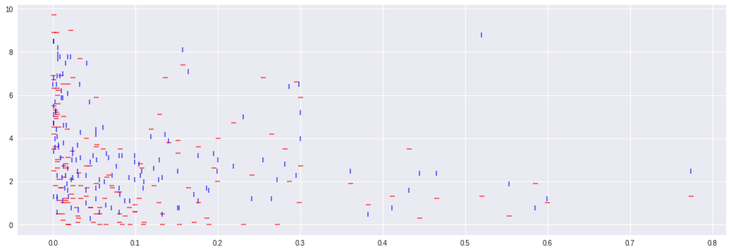

```
Ratio/SHI:  -0.205485969006
Ratio/GRI:  -0.212710605512
```

```python
''' To inspect the correlation of unaffiliated ratio against SHI and GRI '''

# Scatter plot
plt.figure(figsize = (18, 6))
plt.scatter(x = df['Ratio'], y = df['SHI'],
            marker = '_', color = 'red', alpha = 0.6)
plt.scatter(x = df['Ratio'], y = df['GRI'],
            marker = '|', color = 'blue', alpha = 0.6)
plt.show()

# Correlation
corr_shi = df.corr().loc['Ratio', 'SHI']
corr_gri = df.corr().loc['Ratio', 'GRI']
print('Ratio/SHI: ', corr_shi)
print('Ratio/GRI: ', corr_gri)
```

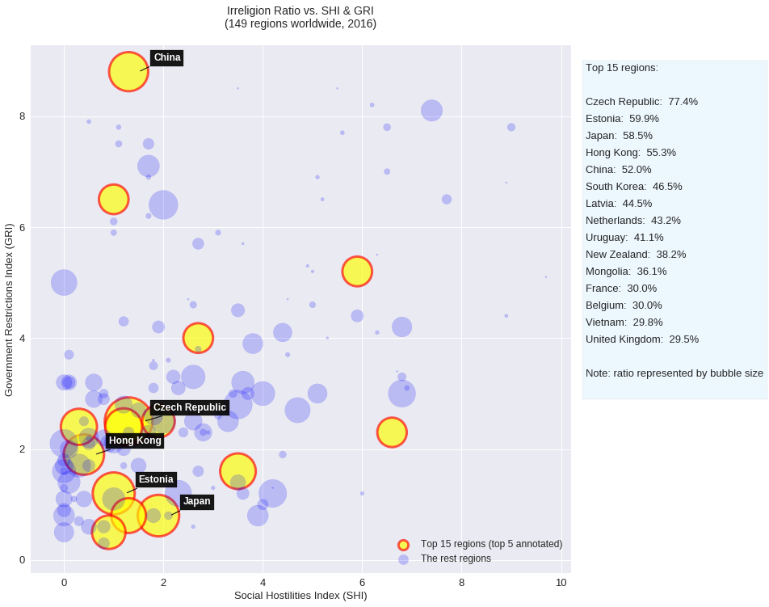

```python
''' To visualize SHI, GRI, and unaffiliated ratio in a single bubble chart '''

plt.figure(figsize = (12, 12))

# Top 10 country with high unaffilidated ratio
plt.scatter(x = df['SHI'][:15], y = df['GRI'][:15], s = df['Ratio'][:15] * 4500,
            color = 'yellow', edgecolors = 'red', linewidths = 3, alpha = 0.65
           )

# All the rest countries
plt.scatter(x = df['SHI'][15:], y = df['GRI'][15:], s = df['Ratio'][15:] * 4500,
            color = 'blue', alpha = 0.2
           )

# Label
plt.title('Irreligion Ratio vs. SHI & GRI' + '\n' +
          '(149 regions worldwide, 2016)' + '\n',
          fontsize = 14
         )
plt.xlabel('Social Hostilities Index (SHI)', fontsize = 13)
plt.xticks(fontsize = 13)
plt.ylabel('Government Restrictions Index (GRI)', fontsize = 13)
plt.yticks(fontsize = 13)

# Legend
lgd = plt.legend(loc = 'lower right',
                 labels = ['Top 15 regions (top 5 annotated)', 'The rest regions'],
                 fontsize = 12
                )
for handle in lgd.legendHandles:
    handle._sizes = [150] # Resize legend marker for consistency

# Annotation
bbox_props = dict(boxstyle = 'square', facecolor = 'black', alpha = 0.9)
arrow_props = dict(arrowstyle = '-', linewidth = 1, facecolor = 'black')
for i in range(5):
    plt.annotate(xy = (df['SHI'][i] + df['Ratio'][i] / 2.5, df['GRI'][i]),
                 xytext = (df['SHI'][i] + 0.5, df['GRI'][i] + 0.2),
                 s = df['Region'][i],
                 fontweight = 'semibold', color = 'white',
                 bbox = bbox_props, arrowprops = arrow_props
                )

# Additional List
text = 'Top 15 regions:' + '\n\n'
for i in range(15):
    text = text + '{}:  {}%\n'.format(df['Region'][i],
                                      round(df['Ratio'][i] * 100,2)
                                     )
text = text + '\n' + 'Note: ratio represented by bubble size' + '\n'
bbox_props = dict(facecolor = 'lightskyblue', alpha = 0.15)
plt.text(x = 10.5, y = 3, s = text, fontsize = 13, linespacing = 2, bbox = bbox_props)

plt.show()
```